# Glue and S3 parameters

```
Distribution of lag_current_ratio, by year and period
```

| pct | year period | lag_current_ratio 2001 | lag_current_ratio 2002 | lag_current_ratio 2003 | lag_current_ratio 2004 | lag_current_ratio 2005 | lag_current_ratio 2006 | lag_current_ratio 2007 |
| --- | --- | --- | --- | --- | --- | --- | --- | --- |
| 0.01 | False | 0.49 | 0.49 | 0.49 | 0.49 | 0.49 | 0.00 | 0.00 |
|  | True | 0.00 | 0.00 | 0.00 | 0.00 | 0.00 | 0.49 | 0.49 |
| 0.05 | False | 0.57 | 0.57 | 0.55 | 0.55 | 0.55 | 0.00 | 0.00 |
|  | True | 0.00 | 0.00 | 0.00 | 0.00 | 0.00 | 0.55 | 0.55 |
| 0.1 | False | 0.60 | 0.60 | 0.57 | 0.57 | 0.57 | 0.00 | 0.00 |
|  | True | 0.00 | 0.00 | 0.00 | 0.00 | 0.00 | 0.57 | 0.57 |
| 0.25 | False | 0.67 | 0.67 | 0.65 | 0.65 | 0.65 | 0.00 | 0.00 |
|  | True | 0.00 | 0.00 | 0.00 | 0.00 | 0.00 | 0.65 | 0.65 |
| 0.5 | False | 0.71 | 0.71 | 0.71 | 0.71 | 0.68 | 0.00 | 0.00 |
|  | True | 0.00 | 0.00 | 0.00 | 0.00 | 0.00 | 0.68 | 0.68 |
| 0.75 | False | 0.87 | 0.87 | 0.86 | 0.86 | 0.77 | 0.00 | 0.00 |
|  | True | 0.00 | 0.00 | 0.00 | 0.00 | 0.00 | 0.77 | 0.77 |
| 0.95 | False | 0.92 | 0.92 | 0.92 | 0.92 | 0.92 | 0.00 | 0.00 |
|  | True | 0.00 | 0.00 | 0.00 | 0.00 | 0.00 | 0.92 | 0.92 |
| 0.99 | False | 0.98 | 0.98 | 0.98 | 0.98 | 0.98 | 0.00 | 0.00 |
|  | True | 0.00 | 0.00 | 0.00 | 0.00 | 0.00 | 0.98 | 0.98 |

```
Distribution of liabilities_tot_asset, by year and period
```

| pct | year period | liabilities_tot_asset 2001 | liabilities_tot_asset 2002 | liabilities_tot_asset 2003 | liabilities_tot_asset 2004 | liabilities_tot_asset 2005 | liabilities_tot_asset 2006 | liabilities_tot_asset 2007 |
| --- | --- | --- | --- | --- | --- | --- | --- | --- |
| 0.01 | False | 0.42 | 0.42 | 0.42 | 0.42 | 0.42 | 0.00 | 0.00 |
|  | True | 0.00 | 0.00 | 0.00 | 0.00 | 0.00 | 0.42 | 0.50 |
| 0.05 | False | 0.50 | 0.50 | 0.50 | 0.50 | 0.50 | 0.00 | 0.00 |
|  | True | 0.00 | 0.00 | 0.00 | 0.00 | 0.00 | 0.50 | 0.50 |
| 0.1 | False | 0.51 | 0.51 | 0.51 | 0.51 | 0.51 | 0.00 | 0.00 |
|  | True | 0.00 | 0.00 | 0.00 | 0.00 | 0.00 | 0.51 | 0.51 |
| 0.25 | False | 0.54 | 0.53 | 0.54 | 0.54 | 0.54 | 0.00 | 0.00 |
|  | True | 0.00 | 0.00 | 0.00 | 0.00 | 0.00 | 0.54 | 0.53 |
| 0.5 | False | 0.57 | 0.57 | 0.57 | 0.57 | 0.57 | 0.00 | 0.00 |
|  | True | 0.00 | 0.00 | 0.00 | 0.00 | 0.00 | 0.57 | 0.57 |
| 0.75 | False | 0.58 | 0.58 | 0.58 | 0.58 | 0.58 | 0.00 | 0.00 |
|  | True | 0.00 | 0.00 | 0.00 | 0.00 | 0.00 | 0.58 | 0.58 |
| 0.95 | False | 0.61 | 0.61 | 0.61 | 0.61 | 0.61 | 0.00 | 0.00 |
|  | True | 0.00 | 0.00 | 0.00 | 0.00 | 0.00 | 0.61 | 0.61 |
| 0.99 | False | 0.61 | 0.61 | 0.65 | 0.65 | 0.65 | 0.00 | 0.00 |
|  | True | 0.00 | 0.00 | 0.00 | 0.00 | 0.00 | 0.65 | 0.65 |

```
Distribution of sales_tot_asset, by year and period
```

| pct | year period | sales_tot_asset 2001 | sales_tot_asset 2002 | sales_tot_asset 2003 | sales_tot_asset 2004 | sales_tot_asset 2005 | sales_tot_asset 2006 | sales_tot_asset 2007 |
| --- | --- | --- | --- | --- | --- | --- | --- | --- |
| 0.01 | False | 0.49 | 0.49 | 0.34 | 0.34 | 0.34 | 0.00 | 0.00 |
|  | True | 0.00 | 0.00 | 0.00 | 0.00 | 0.00 | 0.34 | 0.34 |
| 0.05 | False | 0.49 | 0.49 | 0.49 | 0.49 | 0.49 | 0.00 | 0.00 |
|  | True | 0.00 | 0.00 | 0.00 | 0.00 | 0.00 | 0.49 | 0.49 |
| 0.1 | False | 0.53 | 0.53 | 0.53 | 0.53 | 0.53 | 0.00 | 0.00 |
|  | True | 0.00 | 0.00 | 0.00 | 0.00 | 0.00 | 0.53 | 0.53 |
| 0.25 | False | 0.57 | 0.57 | 0.57 | 0.57 | 0.57 | 0.00 | 0.00 |
|  | True | 0.00 | 0.00 | 0.00 | 0.00 | 0.00 | 0.57 | 0.57 |
| 0.5 | False | 0.62 | 0.62 | 0.62 | 0.62 | 0.62 | 0.00 | 0.00 |
|  | True | 0.00 | 0.00 | 0.00 | 0.00 | 0.00 | 0.62 | 0.62 |
| 0.75 | False | 0.76 | 0.76 | 0.76 | 0.76 | 0.76 | 0.00 | 0.00 |
|  | True | 0.00 | 0.00 | 0.00 | 0.00 | 0.00 | 0.76 | 0.76 |
| 0.95 | False | 1.02 | 1.08 | 1.02 | 1.08 | 1.08 | 0.00 | 0.00 |
|  | True | 0.00 | 0.00 | 0.00 | 0.00 | 0.00 | 1.08 | 1.08 |
| 0.99 | False | 1.27 | 1.27 | 1.27 | 1.27 | 1.27 | 0.00 | 0.00 |
|  | True | 0.00 | 0.00 | 0.00 | 0.00 | 0.00 | 1.27 | 1.27 |

```
Distribution of lag_sales_tot_asset, by year and period
```

| pct | year period | lag_sales_tot_asset 2001 | lag_sales_tot_asset 2002 | lag_sales_tot_asset 2003 | lag_sales_tot_asset 2004 | lag_sales_tot_asset 2005 | lag_sales_tot_asset 2006 | lag_sales_tot_asset 2007 |
| --- | --- | --- | --- | --- | --- | --- | --- | --- |
| 0.01 | False | 0.46 | 0.46 | 0.29 | 0.29 | 0.29 | 0.00 | 0.00 |
|  | True | 0.00 | 0.00 | 0.00 | 0.00 | 0.00 | 0.29 | 0.29 |
| 0.05 | False | 0.46 | 0.46 | 0.46 | 0.46 | 0.46 | 0.00 | 0.00 |
|  | True | 0.00 | 0.00 | 0.00 | 0.00 | 0.00 | 0.46 | 0.46 |
| 0.1 | False | 0.49 | 0.49 | 0.49 | 0.49 | 0.49 | 0.00 | 0.00 |
|  | True | 0.00 | 0.00 | 0.00 | 0.00 | 0.00 | 0.49 | 0.49 |
| 0.25 | False | 0.53 | 0.52 | 0.52 | 0.52 | 0.52 | 0.00 | 0.00 |
|  | True | 0.00 | 0.00 | 0.00 | 0.00 | 0.00 | 0.52 | 0.52 |
| 0.5 | False | 0.59 | 0.59 | 0.59 | 0.59 | 0.59 | 0.00 | 0.00 |
|  | True | 0.00 | 0.00 | 0.00 | 0.00 | 0.00 | 0.59 | 0.59 |
| 0.75 | False | 0.74 | 0.74 | 0.74 | 0.74 | 0.74 | 0.00 | 0.00 |
|  | True | 0.00 | 0.00 | 0.00 | 0.00 | 0.00 | 0.74 | 0.74 |
| 0.95 | False | 1.14 | 1.14 | 1.14 | 1.14 | 1.14 | 0.00 | 0.00 |
|  | True | 0.00 | 0.00 | 0.00 | 0.00 | 0.00 | 1.14 | 1.14 |
| 0.99 | False | 1.20 | 1.20 | 1.20 | 1.20 | 1.20 | 0.00 | 0.00 |
|  | True | 0.00 | 0.00 | 0.00 | 0.00 | 0.00 | 1.20 | 1.20 |

```
Distribution of asset_tangibility_tot_asset, by year and period
```

| pct | year period | asset_tangibility_tot_asset 2001 | asset_tangibility_tot_asset 2002 | asset_tangibility_tot_asset 2003 | asset_tangibility_tot_asset 2004 | asset_tangibility_tot_asset 2005 | asset_tangibility_tot_asset 2006 | asset_tangibility_tot_asset 2007 |
| --- | --- | --- | --- | --- | --- | --- | --- | --- |
| 0.01 | False | 0.33 | 0.33 | 0.33 | 0.33 | 0.33 | 0.00 | 0.00 |
|  | True | 0.00 | 0.00 | 0.00 | 0.00 | 0.00 | 0.33 | 0.33 |
| 0.05 | False | 0.33 | 0.33 | 0.33 | 0.35 | 0.35 | 0.00 | 0.00 |
|  | True | 0.00 | 0.00 | 0.00 | 0.00 | 0.00 | 0.35 | 0.35 |
| 0.1 | False | 0.35 | 0.35 | 0.35 | 0.35 | 0.35 | 0.00 | 0.00 |
|  | True | 0.00 | 0.00 | 0.00 | 0.00 | 0.00 | 0.35 | 0.35 |
| 0.25 | False | 0.39 | 0.39 | 0.39 | 0.39 | 0.39 | 0.00 | 0.00 |
|  | True | 0.00 | 0.00 | 0.00 | 0.00 | 0.00 | 0.39 | 0.39 |
| 0.5 | False | 0.46 | 0.46 | 0.46 | 0.46 | 0.46 | 0.00 | 0.00 |
|  | True | 0.00 | 0.00 | 0.00 | 0.00 | 0.00 | 0.47 | 0.47 |
| 0.75 | False | 0.54 | 0.54 | 0.54 | 0.54 | 0.54 | 0.00 | 0.00 |
|  | True | 0.00 | 0.00 | 0.00 | 0.00 | 0.00 | 0.54 | 0.54 |
| 0.95 | False | 0.64 | 0.64 | 0.64 | 0.64 | 0.64 | 0.00 | 0.00 |
|  | True | 0.00 | 0.00 | 0.00 | 0.00 | 0.00 | 0.64 | 0.64 |
| 0.99 | False | 0.68 | 0.68 | 0.68 | 0.68 | 0.68 | 0.00 | 0.00 |
|  | True | 0.00 | 0.00 | 0.00 | 0.00 | 0.00 | 0.68 | 0.68 |

```
Distribution of lag_liabilities_tot_asset, by year and period
```

| pct | year period | lag_liabilities_tot_asset 2001 | lag_liabilities_tot_asset 2002 | lag_liabilities_tot_asset 2003 | lag_liabilities_tot_asset 2004 | lag_liabilities_tot_asset 2005 | lag_liabilities_tot_asset 2006 | lag_liabilities_tot_asset 2007 |
| --- | --- | --- | --- | --- | --- | --- | --- | --- |
| 0.01 | False | 0.44 | 0.44 | 0.44 | 0.44 | 0.44 | 0.00 | 0.00 |
|  | True | 0.00 | 0.00 | 0.00 | 0.00 | 0.00 | 0.44 | 0.47 |
| 0.05 | False | 0.47 | 0.47 | 0.47 | 0.47 | 0.47 | 0.00 | 0.00 |
|  | True | 0.00 | 0.00 | 0.00 | 0.00 | 0.00 | 0.47 | 0.47 |
| 0.1 | False | 0.51 | 0.51 | 0.51 | 0.51 | 0.51 | 0.00 | 0.00 |
|  | True | 0.00 | 0.00 | 0.00 | 0.00 | 0.00 | 0.51 | 0.51 |
| 0.25 | False | 0.54 | 0.54 | 0.54 | 0.54 | 0.54 | 0.00 | 0.00 |
|  | True | 0.00 | 0.00 | 0.00 | 0.00 | 0.00 | 0.54 | 0.54 |
| 0.5 | False | 0.58 | 0.58 | 0.58 | 0.58 | 0.58 | 0.00 | 0.00 |
|  | True | 0.00 | 0.00 | 0.00 | 0.00 | 0.00 | 0.58 | 0.58 |
| 0.75 | False | 0.59 | 0.59 | 0.59 | 0.59 | 0.59 | 0.00 | 0.00 |
|  | True | 0.00 | 0.00 | 0.00 | 0.00 | 0.00 | 0.59 | 0.59 |
| 0.95 | False | 0.61 | 0.61 | 0.62 | 0.62 | 0.62 | 0.00 | 0.00 |
|  | True | 0.00 | 0.00 | 0.00 | 0.00 | 0.00 | 0.62 | 0.62 |
| 0.99 | False | 0.62 | 0.62 | 0.68 | 0.68 | 0.68 | 0.00 | 0.00 |
|  | True | 0.00 | 0.00 | 0.00 | 0.00 | 0.00 | 0.68 | 0.68 |

```
Distribution of cashflow_to_tangible, by year and period
```

| pct | year period | cashflow_to_tangible 2001 | cashflow_to_tangible 2002 | cashflow_to_tangible 2003 | cashflow_to_tangible 2004 | cashflow_to_tangible 2005 | cashflow_to_tangible 2006 | cashflow_to_tangible 2007 |
| --- | --- | --- | --- | --- | --- | --- | --- | --- |
| 0.01 | False | 0.07 | 0.07 | 0.02 | 0.02 | 0.02 | 0.00 | 0.00 |
|  | True | 0.00 | 0.00 | 0.00 | 0.00 | 0.00 | 0.02 | 0.02 |
| 0.05 | False | 0.07 | 0.07 | 0.07 | 0.07 | 0.07 | 0.00 | 0.00 |
|  | True | 0.00 | 0.00 | 0.00 | 0.00 | 0.00 | 0.07 | 0.07 |
| 0.1 | False | 0.07 | 0.07 | 0.07 | 0.07 | 0.07 | 0.00 | 0.00 |
|  | True | 0.00 | 0.00 | 0.00 | 0.00 | 0.00 | 0.07 | 0.07 |
| 0.25 | False | 0.08 | 0.08 | 0.08 | 0.08 | 0.08 | 0.00 | 0.00 |
|  | True | 0.00 | 0.00 | 0.00 | 0.00 | 0.00 | 0.08 | 0.08 |
| 0.5 | False | 0.10 | 0.10 | 0.10 | 0.10 | 0.10 | 0.00 | 0.00 |
|  | True | 0.00 | 0.00 | 0.00 | 0.00 | 0.00 | 0.10 | 0.10 |
| 0.75 | False | 0.14 | 0.14 | 0.14 | 0.14 | 0.14 | 0.00 | 0.00 |
|  | True | 0.00 | 0.00 | 0.00 | 0.00 | 0.00 | 0.14 | 0.14 |
| 0.95 | False | 0.18 | 0.18 | 0.18 | 0.18 | 0.18 | 0.00 | 0.00 |
|  | True | 0.00 | 0.00 | 0.00 | 0.00 | 0.00 | 0.18 | 0.18 |
| 0.99 | False | 0.25 | 0.25 | 0.25 | 0.25 | 0.25 | 0.00 | 0.00 |
|  | True | 0.00 | 0.00 | 0.00 | 0.00 | 0.00 | 0.25 | 0.20 |

```
Distribution of lag_cashflow_to_tangible, by year and period
```

| pct | year period | lag_cashflow_to_tangible 2001 | lag_cashflow_to_tangible 2002 | lag_cashflow_to_tangible 2003 | lag_cashflow_to_tangible 2004 | lag_cashflow_to_tangible 2005 | lag_cashflow_to_tangible 2006 | lag_cashflow_to_tangible 2007 |
| --- | --- | --- | --- | --- | --- | --- | --- | --- |
| 0.01 | False | 0.05 | 0.05 | 0.01 | 0.01 | 0.01 | 0.00 | 0.00 |
|  | True | 0.00 | 0.00 | 0.00 | 0.00 | 0.00 | 0.01 | 0.01 |
| 0.05 | False | 0.06 | 0.06 | 0.05 | 0.05 | 0.05 | 0.00 | 0.00 |
|  | True | 0.00 | 0.00 | 0.00 | 0.00 | 0.00 | 0.05 | 0.05 |
| 0.1 | False | 0.07 | 0.07 | 0.07 | 0.06 | 0.06 | 0.00 | 0.00 |
|  | True | 0.00 | 0.00 | 0.00 | 0.00 | 0.00 | 0.06 | 0.06 |
| 0.25 | False | 0.07 | 0.07 | 0.07 | 0.07 | 0.07 | 0.00 | 0.00 |
|  | True | 0.00 | 0.00 | 0.00 | 0.00 | 0.00 | 0.07 | 0.07 |
| 0.5 | False | 0.10 | 0.09 | 0.09 | 0.09 | 0.09 | 0.00 | 0.00 |
|  | True | 0.00 | 0.00 | 0.00 | 0.00 | 0.00 | 0.09 | 0.09 |
| 0.75 | False | 0.12 | 0.12 | 0.12 | 0.12 | 0.12 | 0.00 | 0.00 |
|  | True | 0.00 | 0.00 | 0.00 | 0.00 | 0.00 | 0.12 | 0.12 |
| 0.95 | False | 0.18 | 0.18 | 0.18 | 0.17 | 0.17 | 0.00 | 0.00 |
|  | True | 0.00 | 0.00 | 0.00 | 0.00 | 0.00 | 0.17 | 0.17 |
| 0.99 | False | 0.25 | 0.25 | 0.25 | 0.25 | 0.25 | 0.00 | 0.00 |
|  | True | 0.00 | 0.00 | 0.00 | 0.00 | 0.00 | 0.25 | 0.21 |

```
Distribution of cashflow_tot_asset, by year and period
```

| pct | year period | cashflow_tot_asset 2001 | cashflow_tot_asset 2002 | cashflow_tot_asset 2003 | cashflow_tot_asset 2004 | cashflow_tot_asset 2005 | cashflow_tot_asset 2006 | cashflow_tot_asset 2007 |
| --- | --- | --- | --- | --- | --- | --- | --- | --- |
| 0.01 | False | 0.03 | 0.03 | 0.01 | 0.01 | 0.01 | 0.00 | 0.00 |
|  | True | 0.00 | 0.00 | 0.00 | 0.00 | 0.00 | 0.01 | 0.01 |
| 0.05 | False | 0.04 | 0.04 | 0.03 | 0.03 | 0.03 | 0.00 | 0.00 |
|  | True | 0.00 | 0.00 | 0.00 | 0.00 | 0.00 | 0.03 | 0.03 |
| 0.1 | False | 0.04 | 0.04 | 0.04 | 0.04 | 0.04 | 0.00 | 0.00 |
|  | True | 0.00 | 0.00 | 0.00 | 0.00 | 0.00 | 0.04 | 0.04 |
| 0.25 | False | 0.04 | 0.04 | 0.04 | 0.04 | 0.04 | 0.00 | 0.00 |
|  | True | 0.00 | 0.00 | 0.00 | 0.00 | 0.00 | 0.04 | 0.04 |
| 0.5 | False | 0.05 | 0.05 | 0.05 | 0.05 | 0.05 | 0.00 | 0.00 |
|  | True | 0.00 | 0.00 | 0.00 | 0.00 | 0.00 | 0.05 | 0.05 |
| 0.75 | False | 0.06 | 0.06 | 0.06 | 0.06 | 0.06 | 0.00 | 0.00 |
|  | True | 0.00 | 0.00 | 0.00 | 0.00 | 0.00 | 0.06 | 0.06 |
| 0.95 | False | 0.06 | 0.06 | 0.06 | 0.06 | 0.06 | 0.00 | 0.00 |
|  | True | 0.00 | 0.00 | 0.00 | 0.00 | 0.00 | 0.06 | 0.06 |
| 0.99 | False | 0.08 | 0.08 | 0.08 | 0.08 | 0.08 | 0.00 | 0.00 |
|  | True | 0.00 | 0.00 | 0.00 | 0.00 | 0.00 | 0.08 | 0.07 |

```
Distribution of lag_cashflow_tot_asset, by year and period
```

| pct | year period | lag_cashflow_tot_asset 2001 | lag_cashflow_tot_asset 2002 | lag_cashflow_tot_asset 2003 | lag_cashflow_tot_asset 2004 | lag_cashflow_tot_asset 2005 | lag_cashflow_tot_asset 2006 | lag_cashflow_tot_asset 2007 |
| --- | --- | --- | --- | --- | --- | --- | --- | --- |
| 0.01 | False | 0.03 | 0.03 | 0.00 | 0.00 | 0.00 | 0.00 | 0.00 |
|  | True | 0.00 | 0.00 | 0.00 | 0.00 | 0.00 | 0.00 | 0.00 |
| 0.05 | False | 0.03 | 0.03 | 0.03 | 0.03 | 0.03 | 0.00 | 0.00 |
|  | True | 0.00 | 0.00 | 0.00 | 0.00 | 0.00 | 0.03 | 0.03 |
| 0.1 | False | 0.03 | 0.03 | 0.03 | 0.03 | 0.03 | 0.00 | 0.00 |
|  | True | 0.00 | 0.00 | 0.00 | 0.00 | 0.00 | 0.03 | 0.03 |
| 0.25 | False | 0.04 | 0.04 | 0.04 | 0.04 | 0.04 | 0.00 | 0.00 |
|  | True | 0.00 | 0.00 | 0.00 | 0.00 | 0.00 | 0.04 | 0.04 |
| 0.5 | False | 0.04 | 0.04 | 0.04 | 0.04 | 0.04 | 0.00 | 0.00 |
|  | True | 0.00 | 0.00 | 0.00 | 0.00 | 0.00 | 0.04 | 0.04 |
| 0.75 | False | 0.05 | 0.05 | 0.05 | 0.05 | 0.05 | 0.00 | 0.00 |
|  | True | 0.00 | 0.00 | 0.00 | 0.00 | 0.00 | 0.05 | 0.05 |
| 0.95 | False | 0.07 | 0.07 | 0.06 | 0.06 | 0.06 | 0.00 | 0.00 |
|  | True | 0.00 | 0.00 | 0.00 | 0.00 | 0.00 | 0.06 | 0.06 |
| 0.99 | False | 0.08 | 0.08 | 0.08 | 0.08 | 0.08 | 0.00 | 0.00 |
|  | True | 0.00 | 0.00 | 0.00 | 0.00 | 0.00 | 0.08 | 0.07 |

```
Distribution of return_to_sale, by year and period
```

| pct | year period | return_to_sale 2001 | return_to_sale 2002 | return_to_sale 2003 | return_to_sale 2004 | return_to_sale 2005 | return_to_sale 2006 | return_to_sale 2007 |
| --- | --- | --- | --- | --- | --- | --- | --- | --- |
| 0.01 | False | 0.02 | 0.02 | -0.01 | -0.01 | -0.01 | 0.00 | 0.00 |
|  | True | 0.00 | 0.00 | 0.00 | 0.00 | 0.00 | -0.01 | -0.01 |
| 0.05 | False | 0.04 | 0.04 | 0.02 | 0.02 | 0.02 | 0.00 | 0.00 |
|  | True | 0.00 | 0.00 | 0.00 | 0.00 | 0.00 | 0.02 | 0.02 |
| 0.1 | False | 0.04 | 0.04 | 0.04 | 0.04 | 0.04 | 0.00 | 0.00 |
|  | True | 0.00 | 0.00 | 0.00 | 0.00 | 0.00 | 0.04 | 0.04 |
| 0.25 | False | 0.04 | 0.04 | 0.04 | 0.04 | 0.04 | 0.00 | 0.00 |
|  | True | 0.00 | 0.00 | 0.00 | 0.00 | 0.00 | 0.04 | 0.04 |
| 0.5 | False | 0.04 | 0.04 | 0.04 | 0.04 | 0.04 | 0.00 | 0.00 |
|  | True | 0.00 | 0.00 | 0.00 | 0.00 | 0.00 | 0.04 | 0.04 |
| 0.75 | False | 0.05 | 0.05 | 0.05 | 0.05 | 0.05 | 0.00 | 0.00 |
|  | True | 0.00 | 0.00 | 0.00 | 0.00 | 0.00 | 0.05 | 0.05 |
| 0.95 | False | 0.09 | 0.09 | 0.09 | 0.09 | 0.09 | 0.00 | 0.00 |
|  | True | 0.00 | 0.00 | 0.00 | 0.00 | 0.00 | 0.09 | 0.09 |
| 0.99 | False | 0.12 | 0.12 | 0.12 | 0.12 | 0.12 | 0.00 | 0.00 |
|  | True | 0.00 | 0.00 | 0.00 | 0.00 | 0.00 | 0.12 | 0.09 |

```
Distribution of lag_return_to_sale, by year and period
```

| pct | year period | lag_return_to_sale 2001 | lag_return_to_sale 2002 | lag_return_to_sale 2003 | lag_return_to_sale 2004 | lag_return_to_sale 2005 | lag_return_to_sale 2006 | lag_return_to_sale 2007 |
| --- | --- | --- | --- | --- | --- | --- | --- | --- |
| 0.01 | False | -0.00 | -0.00 | -0.05 | -0.05 | -0.05 | 0.00 | 0.00 |
|  | True | 0.00 | 0.00 | 0.00 | 0.00 | 0.00 | -0.05 | -0.05 |
| 0.05 | False | 0.03 | 0.03 | -0.00 | -0.00 | -0.00 | 0.00 | 0.00 |
|  | True | 0.00 | 0.00 | 0.00 | 0.00 | 0.00 | -0.00 | -0.00 |
| 0.1 | False | 0.03 | 0.03 | 0.03 | 0.03 | 0.03 | 0.00 | 0.00 |
|  | True | 0.00 | 0.00 | 0.00 | 0.00 | 0.00 | 0.03 | 0.03 |
| 0.25 | False | 0.03 | 0.03 | 0.03 | 0.03 | 0.03 | 0.00 | 0.00 |
|  | True | 0.00 | 0.00 | 0.00 | 0.00 | 0.00 | 0.03 | 0.03 |
| 0.5 | False | 0.04 | 0.04 | 0.04 | 0.04 | 0.04 | 0.00 | 0.00 |
|  | True | 0.00 | 0.00 | 0.00 | 0.00 | 0.00 | 0.04 | 0.04 |
| 0.75 | False | 0.05 | 0.05 | 0.05 | 0.05 | 0.05 | 0.00 | 0.00 |
|  | True | 0.00 | 0.00 | 0.00 | 0.00 | 0.00 | 0.05 | 0.05 |
| 0.95 | False | 0.08 | 0.08 | 0.08 | 0.08 | 0.08 | 0.00 | 0.00 |
|  | True | 0.00 | 0.00 | 0.00 | 0.00 | 0.00 | 0.08 | 0.08 |
| 0.99 | False | 0.12 | 0.12 | 0.12 | 0.12 | 0.12 | 0.00 | 0.00 |
|  | True | 0.00 | 0.00 | 0.00 | 0.00 | 0.00 | 0.12 | 0.09 |

```
Distribution of fe_c_i, by year and period
```

| pct | year period | fe_c_i 2001 | fe_c_i 2002 | fe_c_i 2003 | fe_c_i 2004 | fe_c_i 2005 | fe_c_i 2006 | fe_c_i 2007 |
| --- | --- | --- | --- | --- | --- | --- | --- | --- |
| 0.01 | False | 49.00 | 45.00 | 77.00 | 49.00 | 51.00 | 0.00 | 0.00 |
|  | True | 0.00 | 0.00 | 0.00 | 0.00 | 0.00 | 51.00 | 57.00 |
| 0.05 | False | 267.00 | 257.00 | 301.00 | 265.00 | 265.00 | 0.00 | 0.00 |
|  | True | 0.00 | 0.00 | 0.00 | 0.00 | 0.00 | 263.00 | 277.00 |
| 0.1 | False | 545.00 | 559.00 | 583.00 | 559.00 | 559.00 | 0.00 | 0.00 |
|  | True | 0.00 | 0.00 | 0.00 | 0.00 | 0.00 | 545.00 | 575.00 |
| 0.25 | False | 1,393.00 | 1,407.00 | 1,463.00 | 1,431.00 | 1,401.00 | 0.00 | 0.00 |
|  | True | 0.00 | 0.00 | 0.00 | 0.00 | 0.00 | 1,351.00 | 1,423.00 |
| 0.5 | False | 2,775.00 | 2,803.00 | 2,835.00 | 2,861.00 | 2,811.00 | 0.00 | 0.00 |
|  | True | 0.00 | 0.00 | 0.00 | 0.00 | 0.00 | 2,943.00 | 2,799.00 |
| 0.75 | False | 4,133.00 | 4,181.00 | 4,199.00 | 4,291.00 | 4,269.00 | 0.00 | 0.00 |
|  | True | 0.00 | 0.00 | 0.00 | 0.00 | 0.00 | 4,363.00 | 4,275.00 |
| 0.95 | False | 5,365.00 | 5,389.00 | 5,365.00 | 5,455.00 | 5,433.00 | 0.00 | 0.00 |
|  | True | 0.00 | 0.00 | 0.00 | 0.00 | 0.00 | 5,471.00 | 5,433.00 |
| 0.99 | False | 5,670.00 | 5,675.00 | 5,683.00 | 5,687.00 | 5,683.00 | 0.00 | 0.00 |
|  | True | 0.00 | 0.00 | 0.00 | 0.00 | 0.00 | 5,695.00 | 5,689.00 |

```
Distribution of fe_t_i, by year and period
```

| pct | year period | fe_t_i 2001 | fe_t_i 2002 | fe_t_i 2003 | fe_t_i 2004 | fe_t_i 2005 | fe_t_i 2006 | fe_t_i 2007 |
| --- | --- | --- | --- | --- | --- | --- | --- | --- |
| 0.01 | False | 1.00 | 29.00 | 58.00 | 87.00 | 116.00 | 0.00 | 0.00 |
|  | True | 0.00 | 0.00 | 0.00 | 0.00 | 0.00 | 145.00 | 174.00 |
| 0.05 | False | 1.00 | 30.00 | 58.00 | 87.00 | 116.00 | 0.00 | 0.00 |
|  | True | 0.00 | 0.00 | 0.00 | 0.00 | 0.00 | 145.00 | 174.00 |
| 0.1 | False | 2.00 | 31.00 | 59.00 | 88.00 | 117.00 | 0.00 | 0.00 |
|  | True | 0.00 | 0.00 | 0.00 | 0.00 | 0.00 | 146.00 | 175.00 |
| 0.25 | False | 6.00 | 35.00 | 64.00 | 92.00 | 121.00 | 0.00 | 0.00 |
|  | True | 0.00 | 0.00 | 0.00 | 0.00 | 0.00 | 150.00 | 179.00 |
| 0.5 | False | 15.00 | 43.00 | 72.00 | 101.00 | 130.00 | 0.00 | 0.00 |
|  | True | 0.00 | 0.00 | 0.00 | 0.00 | 0.00 | 159.00 | 188.00 |
| 0.75 | False | 21.00 | 50.00 | 78.00 | 107.00 | 136.00 | 0.00 | 0.00 |
|  | True | 0.00 | 0.00 | 0.00 | 0.00 | 0.00 | 165.00 | 194.00 |
| 0.95 | False | 26.00 | 55.00 | 84.00 | 112.00 | 141.00 | 0.00 | 0.00 |
|  | True | 0.00 | 0.00 | 0.00 | 0.00 | 0.00 | 170.00 | 199.00 |
| 0.99 | False | 28.00 | 57.00 | 86.00 | 115.00 | 144.00 | 0.00 | 0.00 |
|  | True | 0.00 | 0.00 | 0.00 | 0.00 | 0.00 | 173.00 | 202.00 |

```
Distribution of fe_c_t, by year and period
```

| pct | year period | fe_c_t 2001 | fe_c_t 2002 | fe_c_t 2003 | fe_c_t 2004 | fe_c_t 2005 | fe_c_t 2006 | fe_c_t 2007 |
| --- | --- | --- | --- | --- | --- | --- | --- | --- |
| 0.01 | False | 8.00 | 9.00 | 17.00 | 11.00 | 12.00 | 0.00 | 0.00 |
|  | True | 0.00 | 0.00 | 0.00 | 0.00 | 0.00 | 13.00 | 14.00 |
| 0.05 | False | 71.00 | 72.00 | 80.00 | 74.00 | 75.00 | 0.00 | 0.00 |
|  | True | 0.00 | 0.00 | 0.00 | 0.00 | 0.00 | 76.00 | 84.00 |
| 0.1 | False | 167.00 | 168.00 | 176.00 | 170.00 | 171.00 | 0.00 | 0.00 |
|  | True | 0.00 | 0.00 | 0.00 | 0.00 | 0.00 | 165.00 | 180.00 |
| 0.25 | False | 468.00 | 476.00 | 491.00 | 478.00 | 472.00 | 0.00 | 0.00 |
|  | True | 0.00 | 0.00 | 0.00 | 0.00 | 0.00 | 459.00 | 481.00 |
| 0.5 | False | 878.00 | 886.00 | 901.00 | 909.00 | 896.00 | 0.00 | 0.00 |
|  | True | 0.00 | 0.00 | 0.00 | 0.00 | 0.00 | 932.00 | 891.00 |
| 0.75 | False | 1,305.00 | 1,320.00 | 1,328.00 | 1,357.00 | 1,351.00 | 0.00 | 0.00 |
|  | True | 0.00 | 0.00 | 0.00 | 0.00 | 0.00 | 1,387.00 | 1,353.00 |
| 0.95 | False | 1,768.00 | 1,776.00 | 1,770.00 | 1,806.00 | 1,793.00 | 0.00 | 0.00 |
|  | True | 0.00 | 0.00 | 0.00 | 0.00 | 0.00 | 1,815.00 | 1,795.00 |
| 0.99 | False | 1,888.00 | 1,889.00 | 1,890.00 | 1,898.00 | 1,899.00 | 0.00 | 0.00 |
|  | True | 0.00 | 0.00 | 0.00 | 0.00 | 0.00 | 1,900.00 | 1,901.00 |

## Statistical Analysis

In this section, we are going to perform:

- Chi square test
- Anova test

To see if there is any dependence between the primary key, and the other variables.

Each statistic is saved in the folder `statistical_analysis`

### Chi square test

There are two types of chi-square tests. Both use the chi-square statistic and distribution for different purposes:

- A chi-square goodness of fit test determines if a sample data matches a population. For more details on this type, see: Goodness of Fit Test.
- A chi-square test for independence compares two variables in a contingency table to see if they are related. In a more general sense, it tests to see whether distributions of categorical variables differ from each another.
  - A very small chi square test statistic means that your observed data fits your expected data extremely well. In other words, there is a relationship.
  - A very large chi square test statistic means that the data does not fit very well. In other words, there isn’t a relationship

The formula for the chi-square statistic used in the chi square test is:

$$ \chi_{c}^{2}=\sum \frac{\left(O_{i}-E_{i}\right)^{2}}{E_{i}} $$

The subscript $c$ are the degrees of freedom. $O$ is your observed value and $E$ is your expected value.

A low value for chi-square means there is a high correlation between your two sets of data. In theory, if your observed and expected values were equal ("no difference") then chi-square would be zero — an event that is unlikely to happen in real life

### Anova

An ANOVA test is a way to find out if survey or experiment results are significant. In other words, they help you to figure out if you need to reject the null hypothesis or accept the alternate hypothesis.

Basically, you’re testing groups to see if there’s a difference between them. Examples of when you might want to test different groups:

- A group of psychiatric patients are trying three different therapies: counseling, medication and biofeedback. You want to see if one therapy is better than the others.
- A manufacturer has two different processes to make light bulbs. They want to know if one process is better than the other. Students from different colleges take the same exam. You want to see if one college outperforms the other.

Source:

- [Chi-square](https://www.statisticshowto.com/probability-and-statistics/chi-square/)
- [Anova](https://www.statisticshowto.com/probability-and-statistics/hypothesis-testing/anova/)

By default, use 10% probability

Once again, define the primary key

The notebook is still in development, therefore we compute once again the list of continuous and categorical variables from the data catalog

Please, add any variables you need to exclude from the analysis

### Chi square

```
period
province_en
cityen
geocode4_corr
tcz
spz
ind2
short
polluted_d50i
polluted_d75i
polluted_d80i
polluted_d85i
polluted_d90i
polluted_d95i
polluted_mi
polluted_d50_cit
polluted_d75_cit
polluted_d80_cit
polluted_d85_cit
polluted_d90_cit
polluted_d95_cit
polluted_m_cit
above_average_mandate
d_avg_ij_o_city_mandate
lower_location
larger_location
coastal
```

### Anova

```
tso2
so2_intensity
tso2_mandate_c
avg_ij_o_city_mandate
in_10_000_tonnes
tfp_cit
credit_constraint
supply_all_credit
supply_long_term_credit
share_big_bank_loan
```

|  | year | share_big_bank_loan |
| --- | --- | --- |
| 0 | 2001 | 0.51114,0.51114,... |
| 1 | 2002 | 0.48735,0.48735,... |
| 2 | 2004 | 0.35893,0.35893,... |
| 3 | 2003 | 0.40635,0.44742,... |
| 4 | 2007 | NaN |
| 5 | 2005 | NaN |
| 6 | 2006 | NaN |

```
The variable share_big_bank_loan will be removed from analysis
share_big_loan
```

|  | year | share_big_loan |
| --- | --- | --- |
| 0 | 2002 | 0.42077,0.42077,... |
| 1 | 2001 | 0.46406,0.46406,... |
| 2 | 2003 | 0.36898,0.39965,... |
| 3 | 2005 | NaN |
| 4 | 2004 | 0.33146,0.33146,... |
| 5 | 2006 | NaN |
| 6 | 2007 | NaN |

```
The variable share_big_loan will be removed from analysis
credit_supply
lag_credit_supply
credit_supply_long_term
lag_credit_supply_long_term
credit_supply_short_term
lag_credit_supply_short_term
output
sales
employment
capital
current_asset
tofixed
total_liabilities
total_asset
tangible
cashflow
current_ratio
lag_current_ratio
liabilities_tot_asset
sales_tot_asset
lag_sales_tot_asset
asset_tangibility_tot_asset
lag_liabilities_tot_asset
cashflow_to_tangible
lag_cashflow_to_tangible
cashflow_tot_asset
lag_cashflow_tot_asset
return_to_sale
lag_return_to_sale
fe_c_i
fe_t_i
fe_c_t
```

|  | test | primary_key | secondary_key | statistic | p_value | dof | critical | result |
| --- | --- | --- | --- | --- | --- | --- | --- | --- |
| tso2 | Anova | year | tso2 | 6.32 | 0.00% | - | - | Dependent (fail to reject H0) |
| so2_intensity | Anova | year | so2_intensity | 12.47 | 0.00% | - | - | Dependent (fail to reject H0) |
| tso2_mandate_c | Anova | year | tso2_mandate_c | 2.12 | 5.00% | - | - | Dependent (fail to reject H0) |
| avg_ij_o_city_mandate | Anova | year | avg_ij_o_city_mandate | 0.57 | 75.00% | - | - | Dependent (fail to reject H0) |
| in_10_000_tonnes | Anova | year | in_10_000_tonnes | 2.53 | 2.00% | - | - | Dependent (fail to reject H0) |
| tfp_cit | Anova | year | tfp_cit | 495.10 | 0.00% | - | - | Dependent (fail to reject H0) |
| credit_constraint | Anova | year | credit_constraint | 4.49 | 0.00% | - | - | Dependent (fail to reject H0) |
| supply_all_credit | Anova | year | supply_all_credit | 1.46 | 19.00% | - | - | Dependent (fail to reject H0) |
| supply_long_term_credit | Anova | year | supply_long_term_credit | 3.02 | 1.00% | - | - | Dependent (fail to reject H0) |
| credit_supply | Anova | year | credit_supply | 436.51 | 0.00% | - | - | Dependent (fail to reject H0) |
| lag_credit_supply | Anova | year | lag_credit_supply | 582.16 | 0.00% | - | - | Dependent (fail to reject H0) |
| credit_supply_long_term | Anova | year | credit_supply_long_term | 601.44 | 0.00% | - | - | Dependent (fail to reject H0) |
| lag_credit_supply_long_term | Anova | year | lag_credit_supply_long_term | 1,336.14 | 0.00% | - | - | Dependent (fail to reject H0) |
| credit_supply_short_term | Anova | year | credit_supply_short_term | 2,783.95 | 0.00% | - | - | Dependent (fail to reject H0) |
| lag_credit_supply_short_term | Anova | year | lag_credit_supply_short_term | 1,872.64 | 0.00% | - | - | Dependent (fail to reject H0) |
| output | Anova | year | output | 74.44 | 0.00% | - | - | Dependent (fail to reject H0) |
| sales | Anova | year | sales | 72.94 | 0.00% | - | - | Dependent (fail to reject H0) |
| employment | Anova | year | employment | 19.93 | 0.00% | - | - | Dependent (fail to reject H0) |
| capital | Anova | year | capital | 40.41 | 0.00% | - | - | Dependent (fail to reject H0) |
| current_asset | Anova | year | current_asset | 8.10 | 0.00% | - | - | Dependent (fail to reject H0) |
| tofixed | Anova | year | tofixed | 0.49 | 82.00% | - | - | Dependent (fail to reject H0) |
| total_liabilities | Anova | year | total_liabilities | 2.61 | 2.00% | - | - | Dependent (fail to reject H0) |
| total_asset | Anova | year | total_asset | 2.37 | 3.00% | - | - | Dependent (fail to reject H0) |
| tangible | Anova | year | tangible | 0.47 | 83.00% | - | - | Dependent (fail to reject H0) |
| cashflow | Anova | year | cashflow | 3.85 | 0.00% | - | - | Dependent (fail to reject H0) |
| current_ratio | Anova | year | current_ratio | 12.52 | 0.00% | - | - | Dependent (fail to reject H0) |
| lag_current_ratio | Anova | year | lag_current_ratio | 15.98 | 0.00% | - | - | Dependent (fail to reject H0) |
| liabilities_tot_asset | Anova | year | liabilities_tot_asset | 6.51 | 0.00% | - | - | Dependent (fail to reject H0) |
| sales_tot_asset | Anova | year | sales_tot_asset | 2.32 | 3.00% | - | - | Dependent (fail to reject H0) |
| lag_sales_tot_asset | Anova | year | lag_sales_tot_asset | 1.80 | 9.00% | - | - | Dependent (fail to reject H0) |
| asset_tangibility_tot_asset | Anova | year | asset_tangibility_tot_asset | 8.73 | 0.00% | - | - | Dependent (fail to reject H0) |
| lag_liabilities_tot_asset | Anova | year | lag_liabilities_tot_asset | 6.58 | 0.00% | - | - | Dependent (fail to reject H0) |
| cashflow_to_tangible | Anova | year | cashflow_to_tangible | 13.28 | 0.00% | - | - | Dependent (fail to reject H0) |
| lag_cashflow_to_tangible | Anova | year | lag_cashflow_to_tangible | 15.20 | 0.00% | - | - | Dependent (fail to reject H0) |
| cashflow_tot_asset | Anova | year | cashflow_tot_asset | 12.21 | 0.00% | - | - | Dependent (fail to reject H0) |
| lag_cashflow_tot_asset | Anova | year | lag_cashflow_tot_asset | 14.22 | 0.00% | - | - | Dependent (fail to reject H0) |
| return_to_sale | Anova | year | return_to_sale | 11.47 | 0.00% | - | - | Dependent (fail to reject H0) |
| lag_return_to_sale | Anova | year | lag_return_to_sale | 20.48 | 0.00% | - | - | Dependent (fail to reject H0) |
| fe_c_i | Anova | year | fe_c_i | 1.68 | 12.00% | - | - | Dependent (fail to reject H0) |
| fe_t_i | Anova | year | fe_t_i | 251,003.10 | 0.00% | - | - | Dependent (fail to reject H0) |
| fe_c_t | Anova | year | fe_c_t | 2.46 | 2.00% | - | - | Dependent (fail to reject H0) |
| tcz | Chi Square | year | tcz | 7.83 | 25.00% | 6.00 | 2.20 | Dependent (reject H0) |
| spz | Chi Square | year | spz | 13.99 | 3.00% | 6.00 | 2.20 | Dependent (reject H0) |
| polluted_d50i | Chi Square | year | polluted_d50i | 12.28 | 6.00% | 6.00 | 2.20 | Dependent (reject H0) |
| polluted_d75i | Chi Square | year | polluted_d75i | 10.34 | 11.00% | 6.00 | 2.20 | Dependent (reject H0) |
| polluted_d80i | Chi Square | year | polluted_d80i | 12.65 | 5.00% | 6.00 | 2.20 | Dependent (reject H0) |
| polluted_d85i | Chi Square | year | polluted_d85i | 9.13 | 17.00% | 6.00 | 2.20 | Dependent (reject H0) |
| polluted_mi | Chi Square | year | polluted_mi | 10.34 | 11.00% | 6.00 | 2.20 | Dependent (reject H0) |
| polluted_d50_cit | Chi Square | year | polluted_d50_cit | 3.12 | 79.00% | 6.00 | 2.20 | Dependent (reject H0) |
| polluted_d75_cit | Chi Square | year | polluted_d75_cit | 2.81 | 83.00% | 6.00 | 2.20 | Dependent (reject H0) |
| polluted_d80_cit | Chi Square | year | polluted_d80_cit | 2.27 | 89.00% | 6.00 | 2.20 | Dependent (reject H0) |
| polluted_d85_cit | Chi Square | year | polluted_d85_cit | 2.45 | 87.00% | 6.00 | 2.20 | Dependent (reject H0) |
| polluted_d95_cit | Chi Square | year | polluted_d95_cit | 5.78 | 45.00% | 6.00 | 2.20 | Dependent (reject H0) |
| polluted_m_cit | Chi Square | year | polluted_m_cit | 3.91 | 69.00% | 6.00 | 2.20 | Dependent (reject H0) |
| above_average_mandate | Chi Square | year | above_average_mandate | 15.24 | 2.00% | 6.00 | 2.20 | Dependent (reject H0) |
| d_avg_ij_o_city_mandate | Chi Square | year | d_avg_ij_o_city_mandate | 5.74 | 45.00% | 6.00 | 2.20 | Dependent (reject H0) |
| lower_location | Chi Square | year | lower_location | 62.94 | 0.00% | 24.00 | 15.66 | Dependent (reject H0) |
| larger_location | Chi Square | year | larger_location | 52.34 | 0.00% | 12.00 | 6.30 | Dependent (reject H0) |
| coastal | Chi Square | year | coastal | 7.92 | 24.00% | 6.00 | 2.20 | Dependent (reject H0) |
| period | Chi Square | year | period | - | - | 6.00 | 2.20 | Independent (fail to reject H0) |
| province_en | Chi Square | year | province_en | - | - | 174.00 | 150.56 | Independent (fail to reject H0) |
| cityen | Chi Square | year | cityen | - | - | 1,674.00 | 1,600.29 | Independent (fail to reject H0) |
| geocode4_corr | Chi Square | year | geocode4_corr | - | - | 1,704.00 | 1,629.63 | Independent (fail to reject H0) |
| ind2 | Chi Square | year | ind2 | - | - | 168.00 | 144.98 | Independent (fail to reject H0) |
| short | Chi Square | year | short | - | - | 168.00 | 144.98 | Independent (fail to reject H0) |
| polluted_d90i | Chi Square | year | polluted_d90i | 2.13 | 91.00% | 6.00 | 2.20 | Independent (fail to reject H0) |
| polluted_d95i | Chi Square | year | polluted_d95i | 0.79 | 99.00% | 6.00 | 2.20 | Independent (fail to reject H0) |
| polluted_d90_cit | Chi Square | year | polluted_d90_cit | 2.00 | 92.00% | 6.00 | 2.20 | Independent (fail to reject H0) |

To visualize in more detail the contency table, you can use the function `contengency_table`. The function parses the folder `statistical_analysis/chi-square`. Five tables are generated:

- Contengency table full: contengency
- Pearson contribution: pearson_residual
- Centengency table percentage row-wise: pct_row
- Centengency table percentage column-wise: pct_columns
- Centengency table percentage full: pct_total

## Graphs

- Heatmap
- Diverging bar
- Scatter plot
- Correspondance analysis

### Heatmap

- heatmap, code by [Seaborn](https://seaborn.pydata.org/examples/many_pairwise_correlations.html)

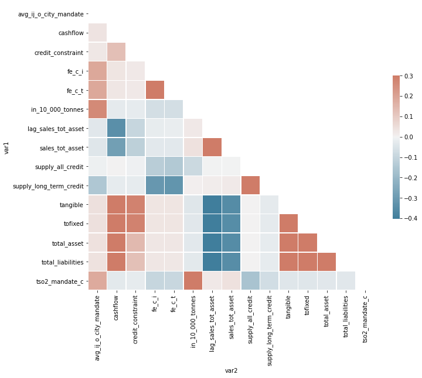

## Scatterplot

From the correlation plot above, pick up a $y$ variables.

Besides, to avoid loading all the table, we have implemented the following rule:

if the size of the table is above >150K rows, then we randomly load 150K rows

First of all, you need to define the Y-axis variables

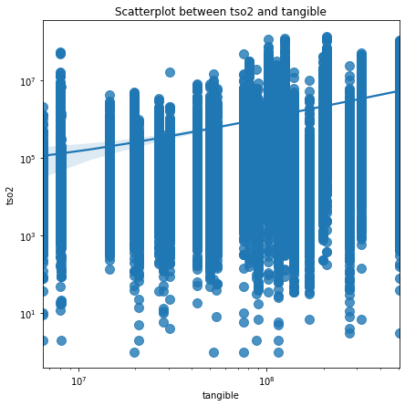

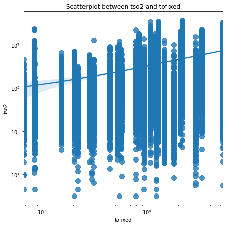

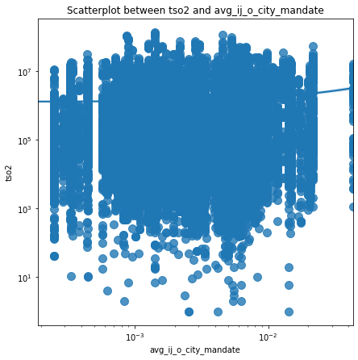

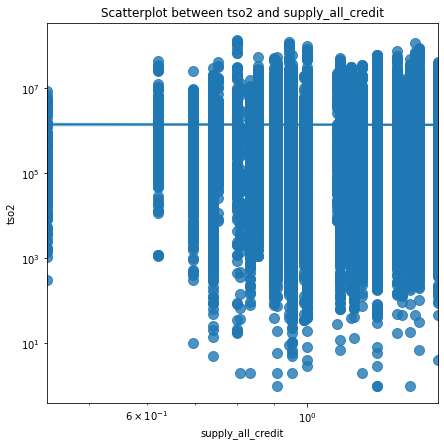

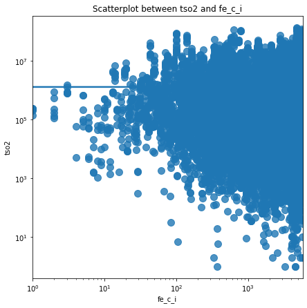

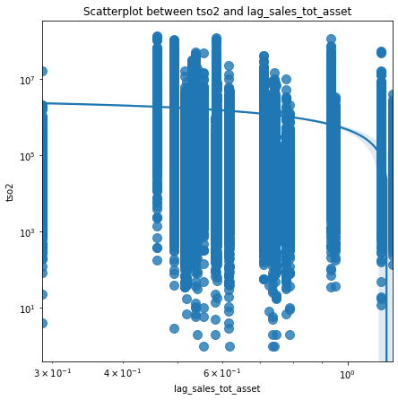

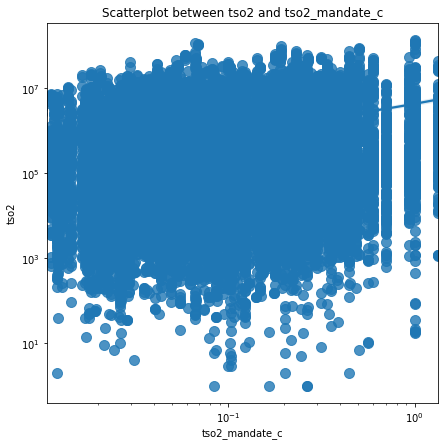

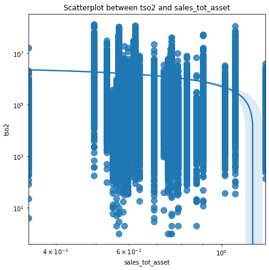

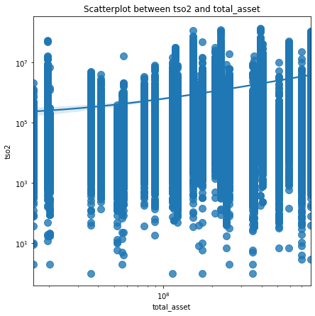

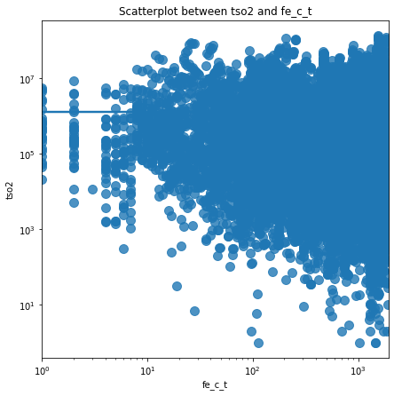

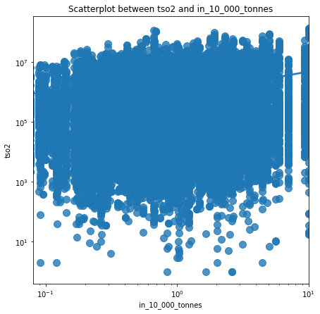

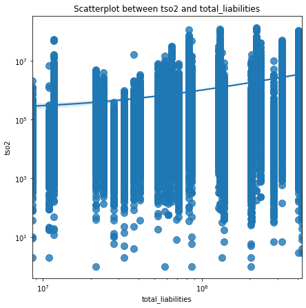

[3 more figures not shown]

### Diverging bars

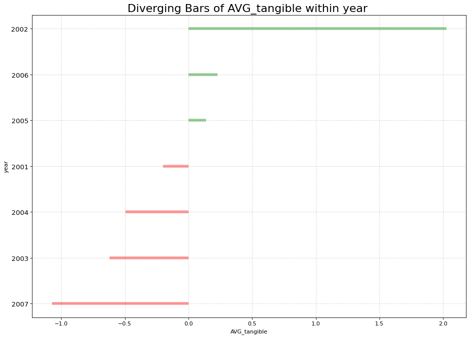

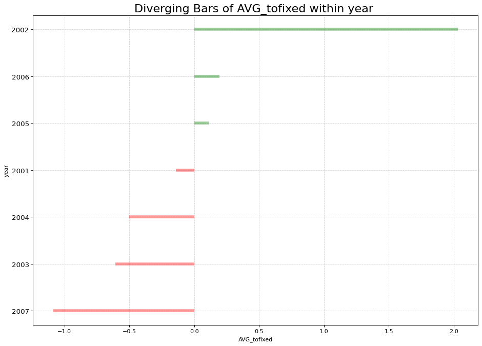

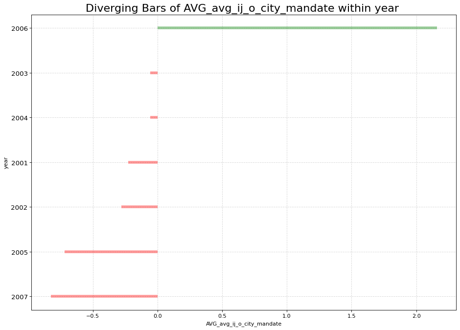

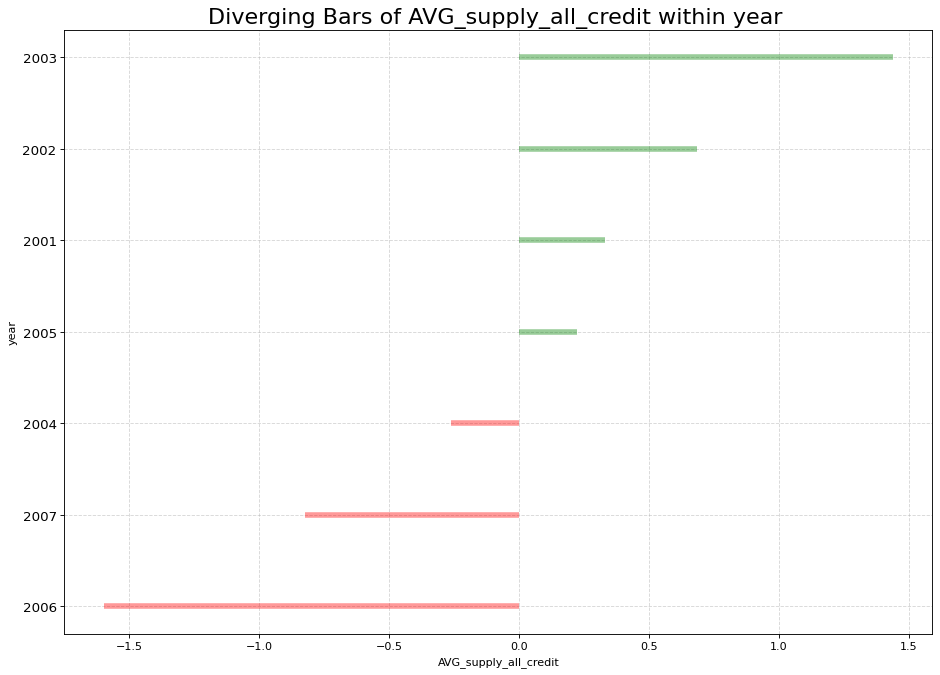

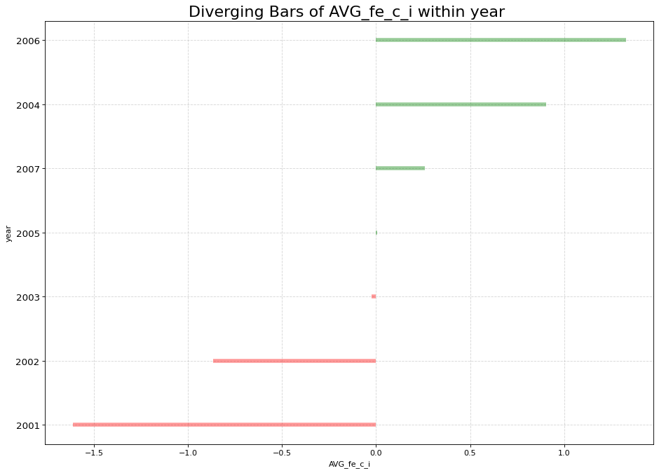

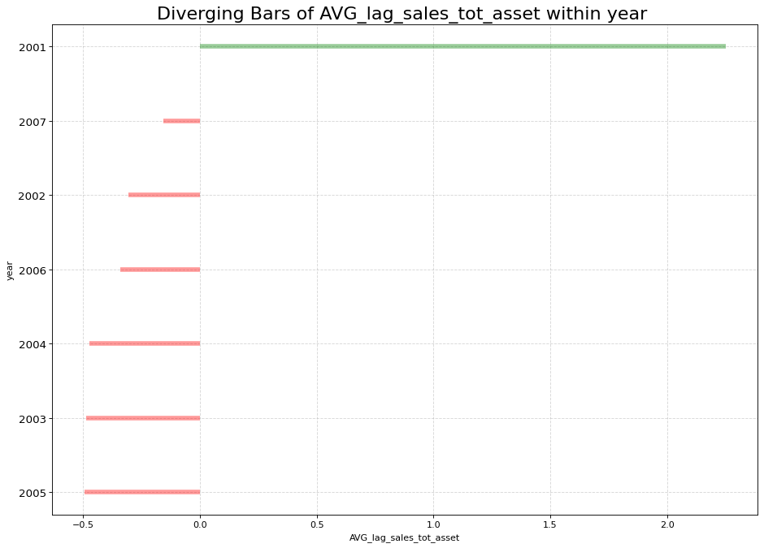

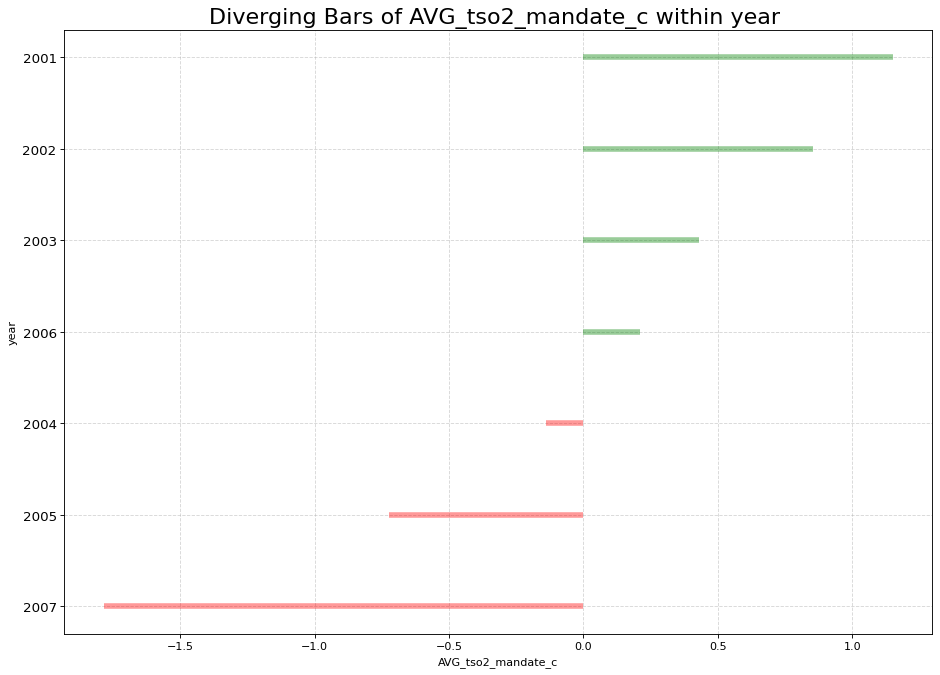

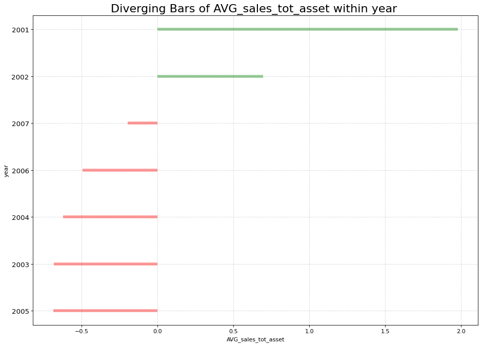

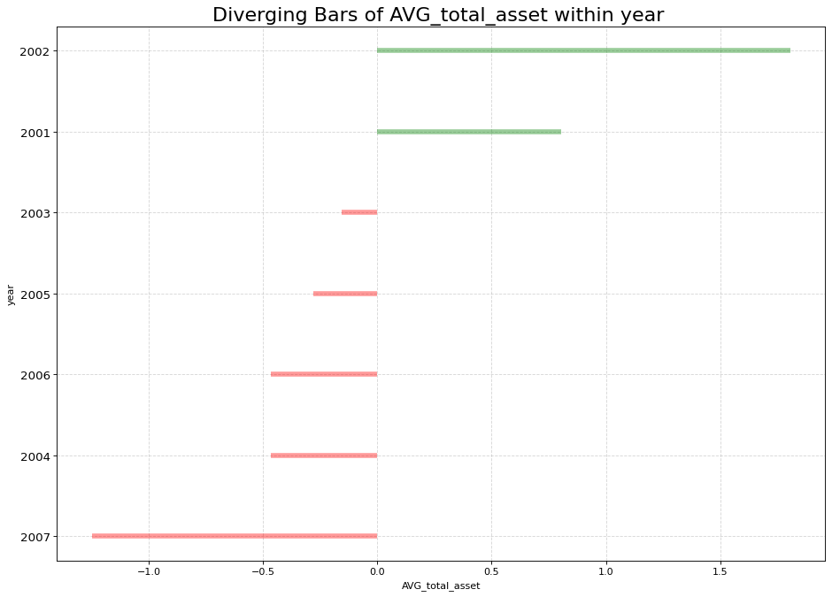

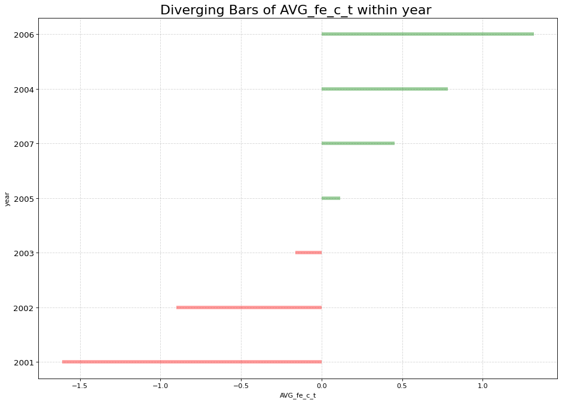

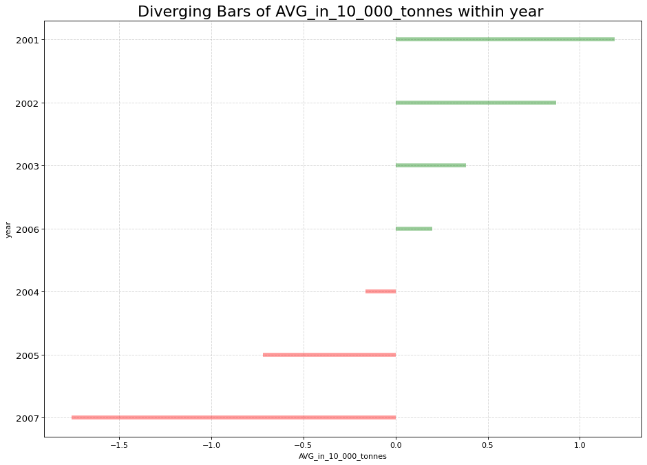

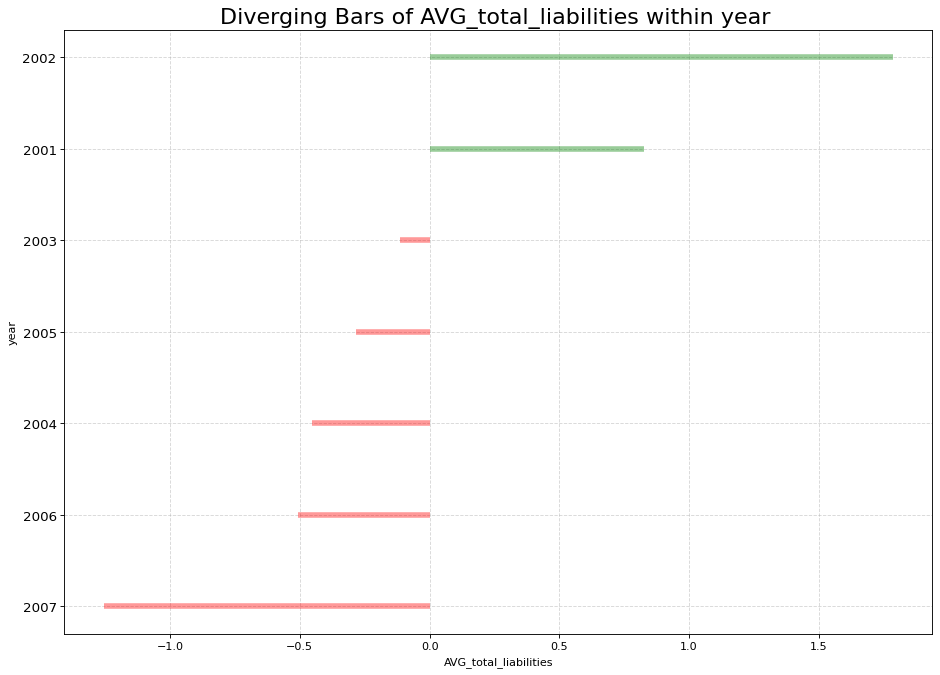

[3 more figures not shown]